# R Project 1 - Hello R

Ashly Garcia

9/16/2020

### Load packages

```r
library(tidyverse)
library(datasauRus)
```

### Exercise 1

The datasaurus_dozen file has 1846 rows and 3 columns. It includes a total of 3 variables which are the dataset (labels from which dataset the data is taken from), x (x-values) and y(y-values).

### Exercise 2

First let’s plot the data in the dino dataset:

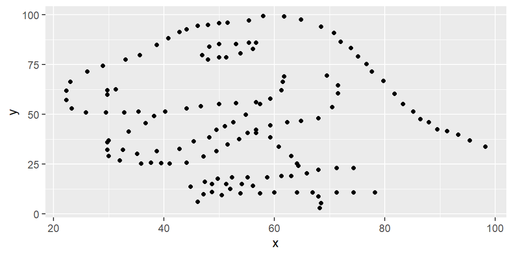

```r
dino_data <- datasaurus_dozen %>%
  filter(dataset == "dino")
ggplot(data = dino_data, mapping = aes(x = x, y = y)) +
  geom_point()
```

And next calculate the correlation between `x` and `y` in this dataset:

```r
dino_data %>%
  summarize(r = cor(x, y))
```

```
## # A tibble: 1 x 1
##         r
##     <dbl>
## 1 -0.0645
```

### Exercise 3

Now, we will reuse the code chunk in lines 26-29 in order to plot the x vs. y for the “star” dataset, and visualize the correlation between the two variables for the star dataset.

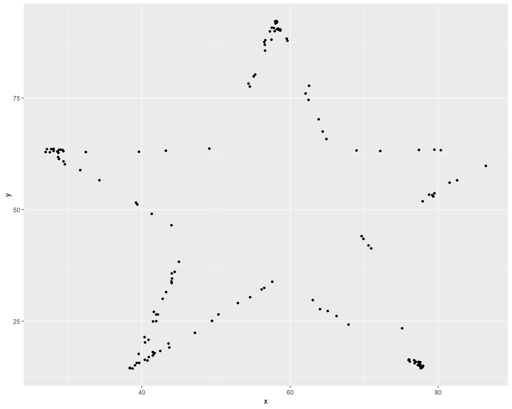

```r
dino_data <- datasaurus_dozen %>%
  filter(dataset == "star")
ggplot(data = dino_data, mapping = aes(x = x, y = y)) +
  geom_point()
```

Next, we can calculate “r” (the correlation coefficient) for the “star” data set to see how it compares to that of the “dino” dataset from Exercise 2.

```r
dino_data %>%
  summarize(r = cor(x, y))
```

```
## # A tibble: 1 x 1
##         r
##     <dbl>
## 1 -0.0630
```

Through this calculation, we can see that the r value between x and y in the “dino” dataset is slightly closer to -1 that of x and y from the “star” dataset. Remember, both datasets show a negative r-value (correlation coefficient) between x and y, however, one is closer to -1 than the other. Since the r value from the “dino” dataset is closer to -1, this means the negative correlation between x and y in the “dino” dataset is stronger than within the “star” dataset.

### Exercise 4

Again, we will reuse the code chunk in lines 26-29 in order to plot the x vs. y for the “circle” dataset, and visualize the correlation between the two variables for this new dataset.

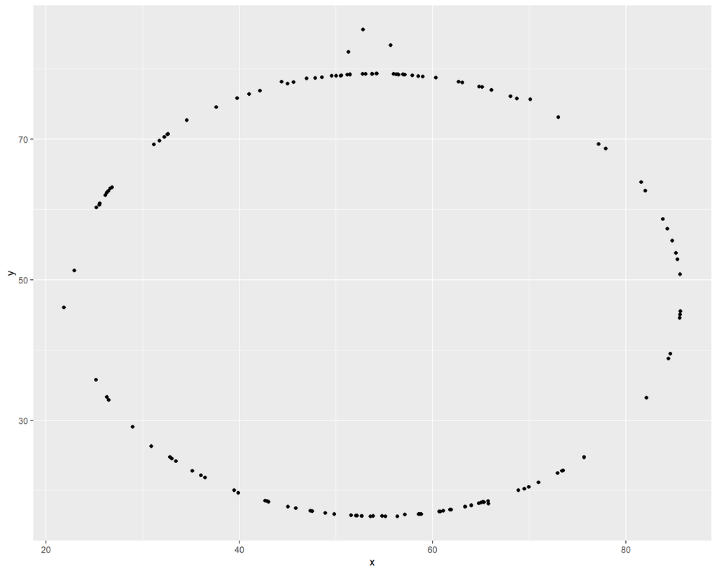

```r
dino_data <- datasaurus_dozen %>%
  filter(dataset == "circle")
ggplot(data = dino_data, mapping = aes(x = x, y = y)) +
  geom_point()
```

Next, we just reuse the code for summarizing the correlation coefficient in order to find that correlation factor for the x and y values in the “circle” dataset.

```r
dino_data %>%
  summarize(r = cor(x, y))
```

```
## # A tibble: 1 x 1
##         r
##     <dbl>
## 1 -0.0683
```

If we compare “r” for the circle dataset, we see that it is closer to -1 than that of the “dino” dataset. So, in this case the negative correlation between x and y within the circle dataset is stronger than the one between x and y in the “dino” dataset.

### Exercise 5

Finally, let’s wrap everything together into a set of panels that will plot x vs. y for all of our different datasets using the following code for faceting,

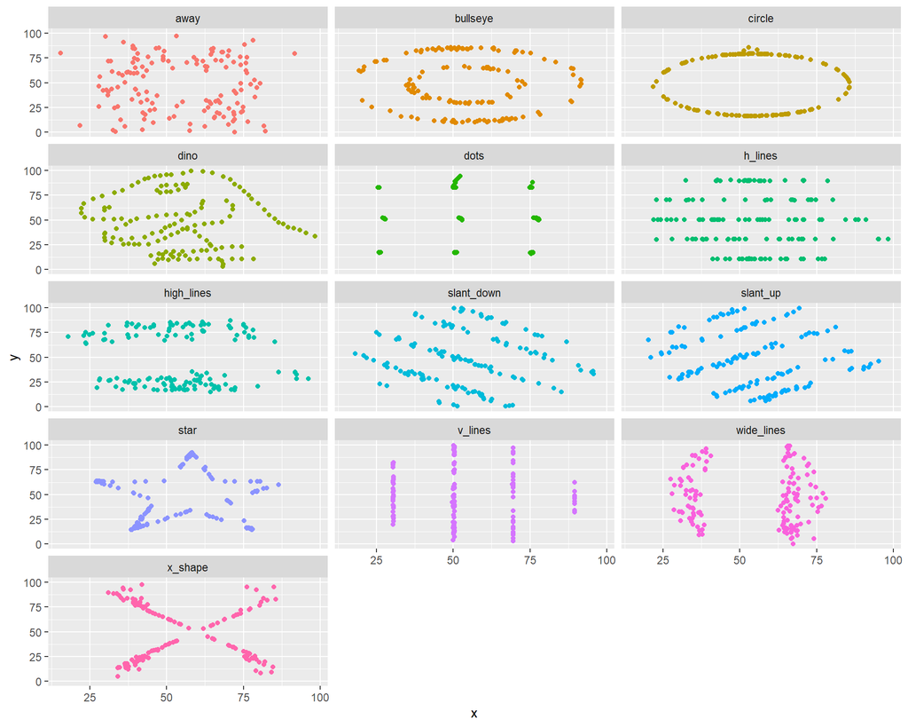

```r
ggplot(datasaurus_dozen, aes(x = x, y = y, color = dataset))+
geom_point()+
facet_wrap(~ dataset, ncol = 3) + # facet the dataset variable, in 3 cols
theme(legend.position = "none")
```

Now to really end it all, we can use the group_by function in order to compile all of the summarized “r” values of our different datasets.

```r
datasaurus_dozen %>%
group_by(dataset) %>%
summarize(r = cor(x, y)) %>%
print(13)
```

```
## # A tibble: 13 x 2
##    dataset          r
##    <chr>        <dbl>
##  1 away       -0.0641
##  2 bullseye   -0.0686
##  3 circle     -0.0683
##  4 dino       -0.0645
##  5 dots       -0.0603
##  6 h_lines    -0.0617
##  7 high_lines -0.0685
##  8 slant_down -0.0690
##  9 slant_up   -0.0686
## 10 star       -0.0630
## 11 v_lines    -0.0694
## 12 wide_lines -0.0666
## 13 x_shape    -0.0656
```